# Online shoppers’ purchasing intention

JUNO CHONG

## Analysis report about online shoppers’ purchasing intention

I am going to explore the online shoppers’ purchasing intention variable that can used for formulating customized promotions.

```r
setwd("C:/B452f")
library(dplyr)
```

```r
library(ggplot2)
library(psych)
library(corrplot)
library(VIM)
library(gridExtra)
library(car)
library(knitr)
library(gmodels)
dat <- read.csv("online_shoppers.csv", header=TRUE)
describe(dat[,1:18])
```

```
##                         vars     n    mean      sd median trimmed    mad min
## Administrative             1 12330    2.32    3.32   1.00    1.63   1.48   0
## Administrative_Duration    2 12330   80.82  176.78   7.50   42.10  11.12   0
## Informational              3 12330    0.50    1.27   0.00    0.18   0.00   0
## Informational_Duration     4 12330   34.47  140.75   0.00    3.59   0.00   0
## ProductRelated             5 12330   31.73   44.48  18.00   22.75  19.27   0
## ProductRelated_Duration    6 12330 1194.75 1913.67 598.94  820.08 742.69   0
## BounceRates                7 12330    0.02    0.05   0.00    0.01   0.00   0
## ExitRates                  8 12330    0.04    0.05   0.03    0.03   0.02   0
## PageValues                 9 12330    5.89   18.57   0.00    1.29   0.00   0
## SpecialDay                10 12330    0.06    0.20   0.00    0.00   0.00   0
## Month*                    11 12330    6.16    2.37   7.00    6.35   1.48   1
## OperatingSystems          12 12330    2.12    0.91   2.00    2.06   0.00   1
## Browser                   13 12330    2.36    1.72   2.00    2.00   0.00   1
## Region                    14 12330    3.15    2.40   3.00    2.79   2.97   1
## TrafficType               15 12330    4.07    4.03   2.00    3.21   1.48   1
## Weekend                   16 12330     NaN      NA     NA     NaN     NA Inf
## Revenue                   17 12330     NaN      NA     NA     NaN     NA Inf
## VisitorType               18 12330    0.13    0.36   0.00    0.05   0.00  -1
##                              max    range  skew kurtosis    se
## Administrative             27.00    27.00  1.96     4.70  0.03
## Administrative_Duration  3398.75  3398.75  5.61    50.53  1.59
## Informational              24.00    24.00  4.04    26.92  0.01
## Informational_Duration   2549.38  2549.38  7.58    76.27  1.27
## ProductRelated            705.00   705.00  4.34    31.19  0.40
## ProductRelated_Duration 63973.52 63973.52  7.26   137.10 17.23
## BounceRates                 0.20     0.20  2.95     7.72  0.00
## ExitRates                   0.20     0.20  2.15     4.01  0.00
## PageValues                361.76   361.76  6.38    65.60  0.17
## SpecialDay                  1.00     1.00  3.30     9.91  0.00
## Month*                     10.00     9.00 -0.83    -0.37  0.02
## OperatingSystems            8.00     7.00  2.07    10.45  0.01
## Browser                    13.00    12.00  3.24    12.74  0.02
## Region                      9.00     8.00  0.98    -0.15  0.02
## TrafficType                20.00    19.00  1.96     3.48  0.04
## Weekend                     -Inf     -Inf    NA       NA    NA
## Revenue                     -Inf     -Inf    NA       NA    NA
## VisitorType                 1.00     2.00  1.73     2.56  0.00
```

```r
dat <- dat %>% select(Administrative, Administrative_Duration, Informational, Informational_Duration, ProductRelated, ProductRelated_Duration,BounceRates, ExitRates,
 PageValues, SpecialDay,Month, OperatingSystems, Browser,Region, TrafficType,Weekend, Revenue, VisitorType)
```

## Descriptive statistics

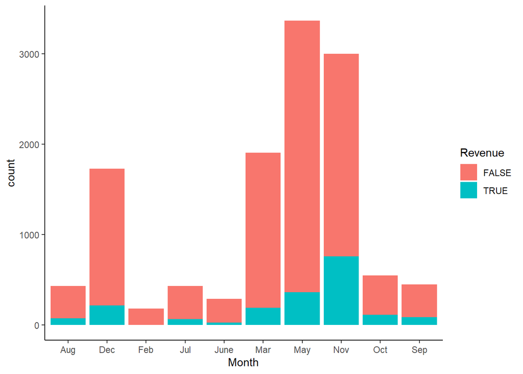

```r
library(dplyr)
# Step 1


ggplot(dat, aes(Month, fill= Revenue)) +
    geom_bar() +
    theme_classic()
```

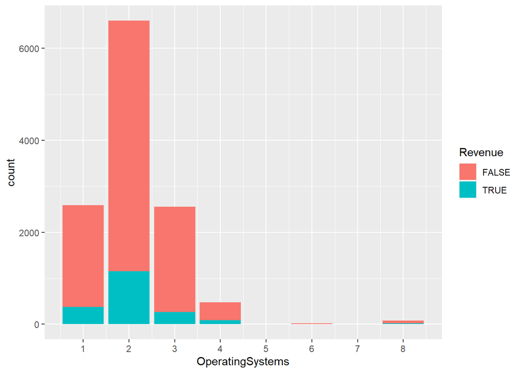

```r
library(dplyr)
# Step 1


ggplot(dat, aes(OperatingSystems, fill = Revenue)) +
    geom_bar() + scale_x_continuous(breaks = seq(1,8, by = 1))
```

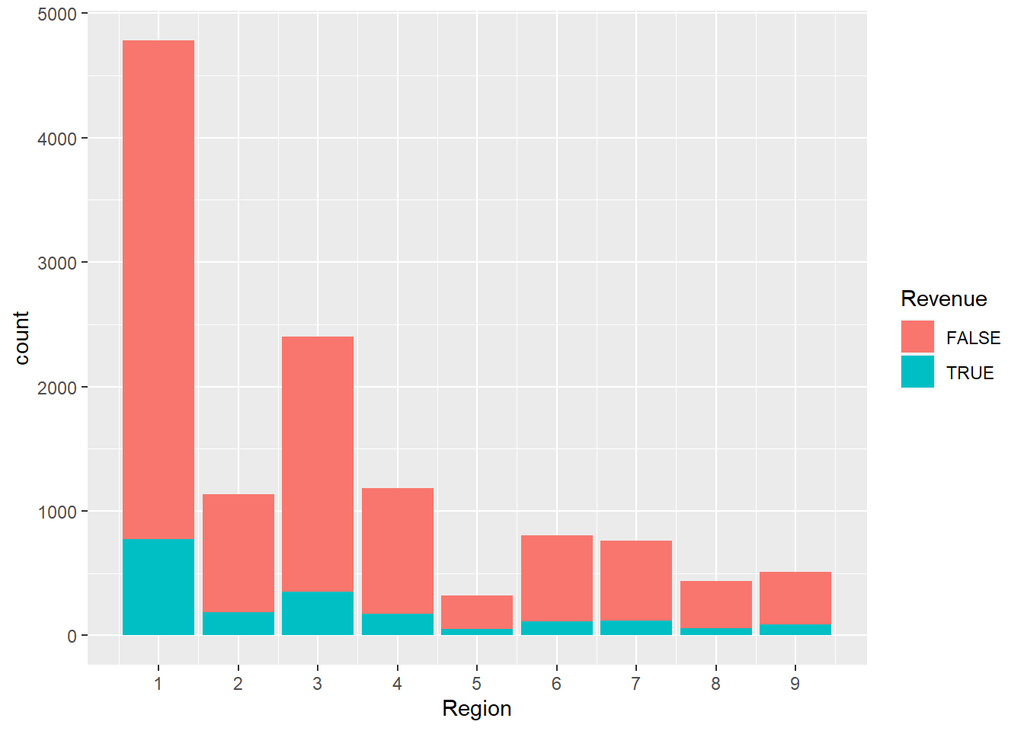

```r
library(dplyr)
# Step 1


ggplot(dat, aes(Region, fill = Revenue)) +
    geom_bar() + scale_x_continuous(breaks = seq(1,10, by = 1))
```

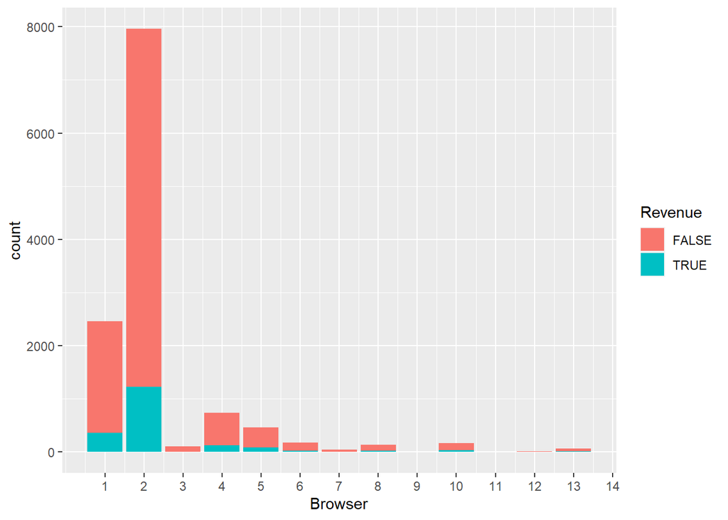

```r
library(dplyr)
# Step 1


ggplot(dat, aes(Browser, fill = Revenue)) +
    geom_bar() +scale_x_continuous(breaks = seq(1,15, by = 1))
```

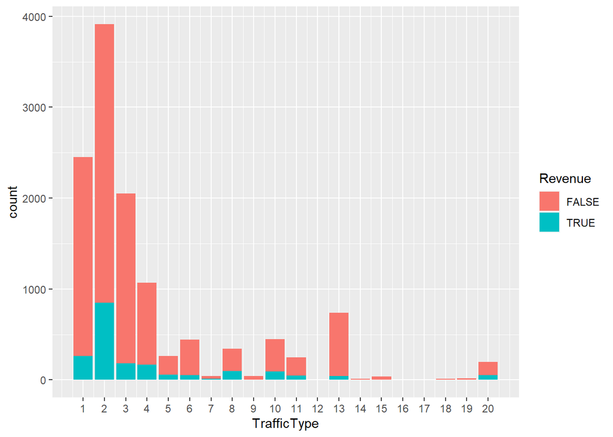

```r
library(dplyr)
# Step 1


ggplot(dat, aes(TrafficType, fill = Revenue)) +
    geom_bar() + scale_x_continuous(breaks = seq(1,20, by = 1))
```

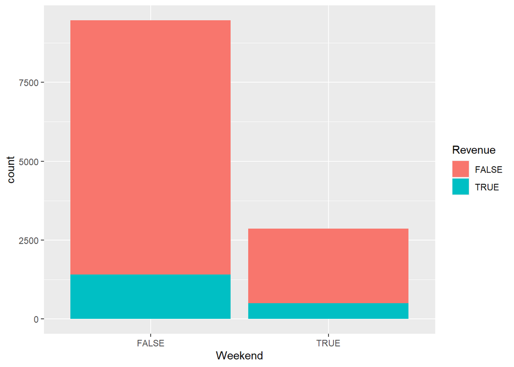

```r
library(dplyr)
# Step 1


ggplot(dat, aes(Weekend, fill = Revenue)) +
    geom_bar()
```

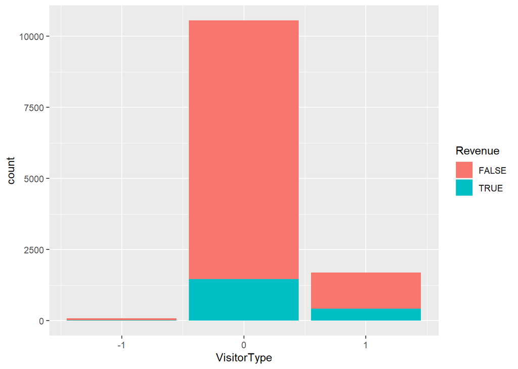

```r
library(dplyr)
# Step 1


ggplot(dat, aes(VisitorType, fill = Revenue)) +
    geom_bar()
```

From the above histogram, we able to have a better insight about the relationship of revenue and other categorical variables. November are the highest month of revenue, OperatingSystems2 has the highest count from users and highest count from buyers. Region1 has the highest count from users and highest count from buyers. Browser2 has the highest count from users and highest count from buyers. Traffictype2 has the most count of users and buyers, second best is Traffictype1. Users and buyers usually make online transaction in weekdays more than weekend. VistorType=0 mean Users and Buyers mainly Returning Visitor will make online transaction.

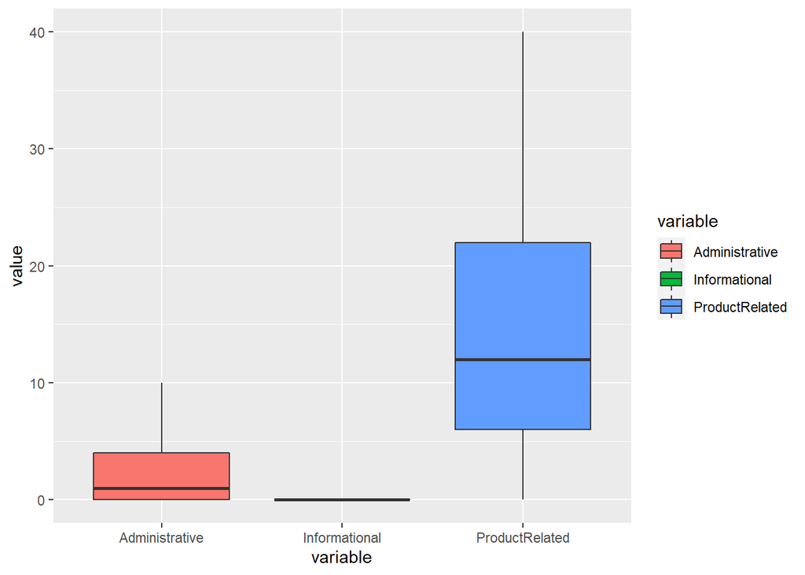

```r
dat %>% select(PageValues, Administrative, Informational, ProductRelated ) %>%
  reshape2::melt(id="PageValues") %>%
  ggplot(aes(x=variable, y=value, fill=variable)) +
  geom_boxplot(outlier.shape = NA) +
  ylim(NA, 40)
```

```r
  labs(x="Characterisitcs", y="PageValues",
       title="administrative/Informational/ProductRelated") +
  theme(plot.title=element_text(hjust=0.5))
```

For the above result, after remove the outliner, we able to find that people using Product Related page have a higher value of the Pagevalues, it means that people who looking in Product related page may have higher intention to completing transaction. But in the data, which there’s a lot of user who aren’t buying after checking all the page. Since I want to know that user who is completed transaction and the number of pages they were checking. I will remove that data row which in Revenue column contains False in analysis and make hypothesis.

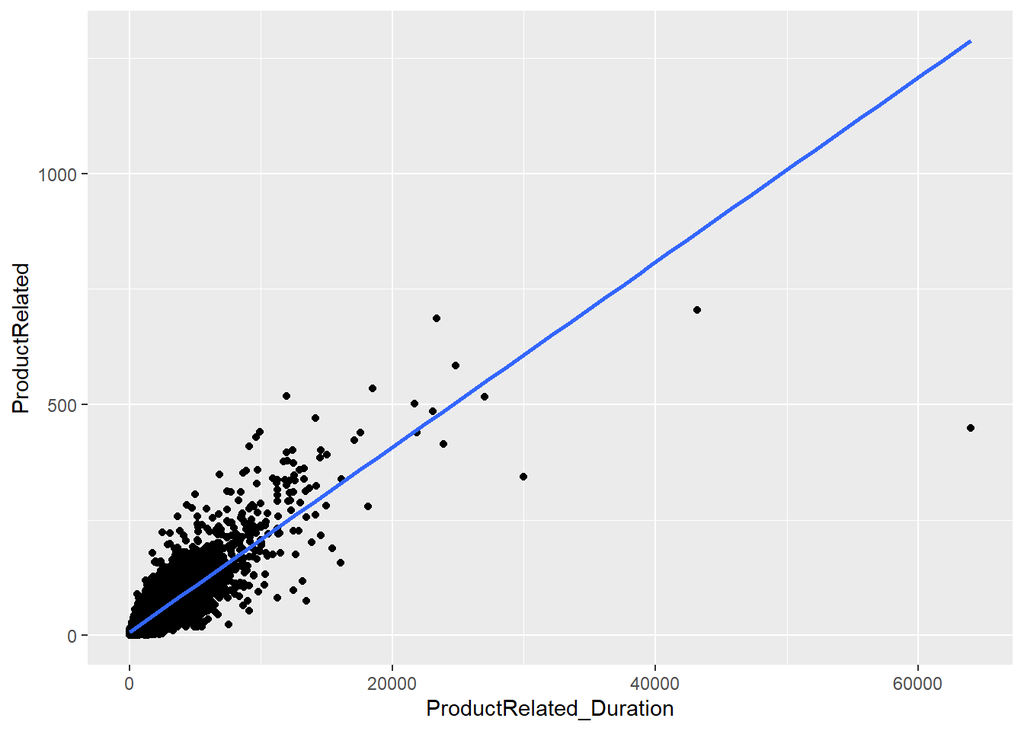

```r
ggplot(dat, aes(x = ProductRelated_Duration, y = ProductRelated)) +
    geom_point()+
  geom_smooth(method=lm, se=FALSE)
```

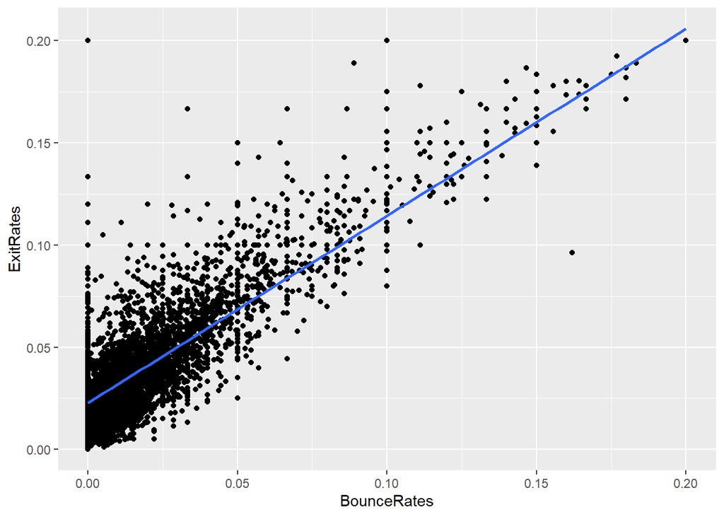

```r
ggplot(dat, aes(x = BounceRates, y = ExitRates)) +
    geom_point()+
  geom_smooth(method=lm, se=FALSE)
```

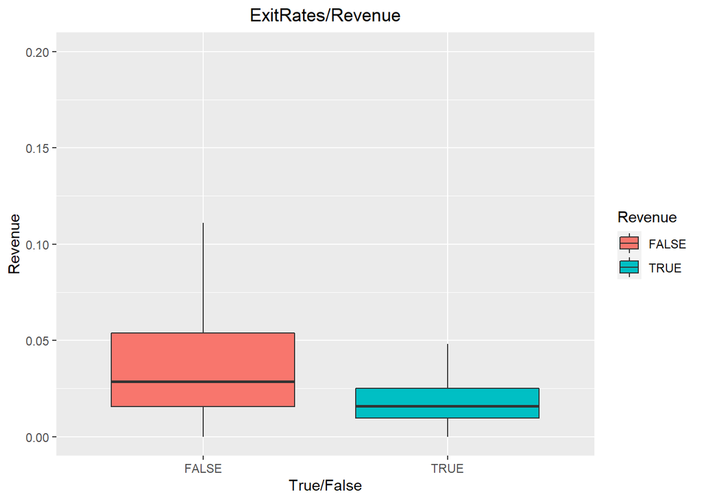

```r
dat %>% select(ExitRates, Revenue) %>%

  ggplot(aes(x=Revenue, y=ExitRates, fill=Revenue)) +
  geom_boxplot(outlier.shape = NA) +

  labs(x="True/False", y="Revenue",
       title="ExitRates/Revenue") +
  theme(plot.title=element_text(hjust=0.5))
```

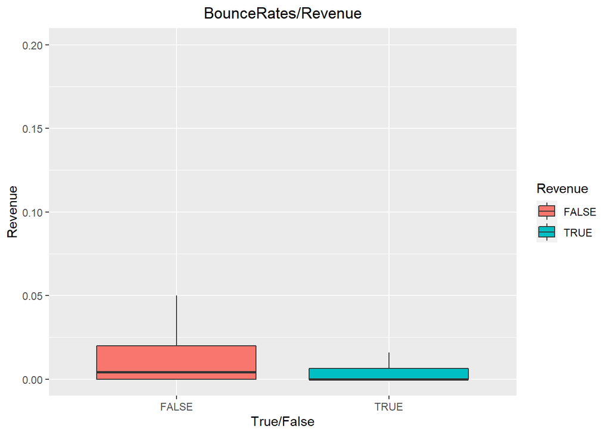

```r
dat %>% select(BounceRates, Revenue) %>%

  ggplot(aes(x=Revenue, y=BounceRates, fill=Revenue)) +
  geom_boxplot(outlier.shape = NA) +

  labs(x="True/False", y="Revenue",
       title="BounceRates/Revenue") +
  theme(plot.title=element_text(hjust=0.5))
```

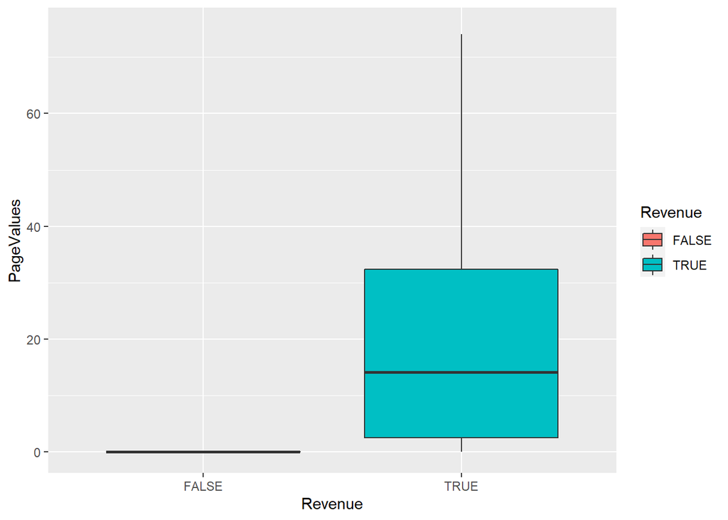

```r
dat %>% select(PageValues ,Revenue) %>%

  ggplot(aes(x=Revenue, y=PageValues, fill=Revenue)) +
  geom_boxplot(outlier.shape = NA) +
 ylim(NA, 75)
```

```r
  labs(x="Characterisitcs", y="PageValues",
       title="PageValues/Revenue") +
  theme(plot.title=element_text(hjust=0.5))
```

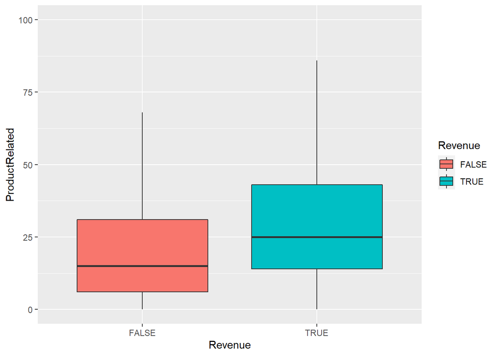

```r
dat %>% select(ProductRelated, Revenue) %>%

  ggplot(aes(x=Revenue, y=ProductRelated, fill=Revenue)) +
 geom_boxplot(outlier.shape = NA) +
 ylim(NA, 100)
```

```r
  labs(x="True/False", y="Revenues",
       title="ProductRelated/Revenue") +
  theme(plot.title=element_text(hjust=0.5))
```

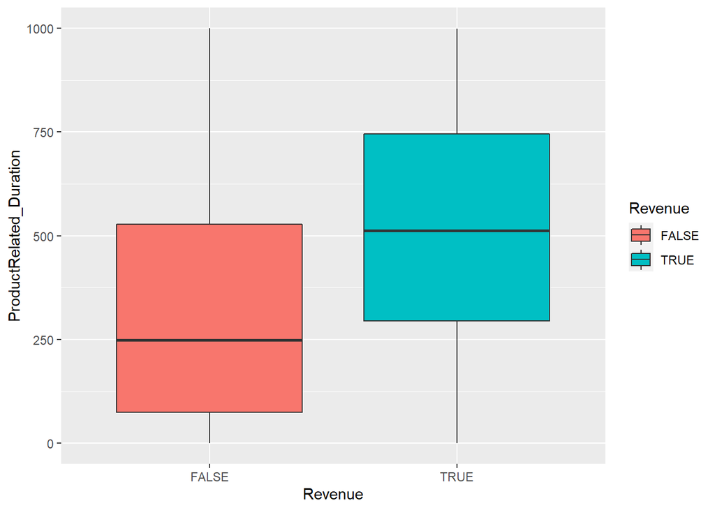

```r
dat %>% select(ProductRelated_Duration, Revenue) %>%

  ggplot(aes(x=Revenue, y=ProductRelated_Duration, fill=Revenue)) +
 geom_boxplot(outlier.shape = NA) +
 ylim(NA, 1000)
```

```r
  labs(x="True/False", y="Revenues",
       title="ProductRelated_Duration/Revenue") +
  theme(plot.title=element_text(hjust=0.5))
```

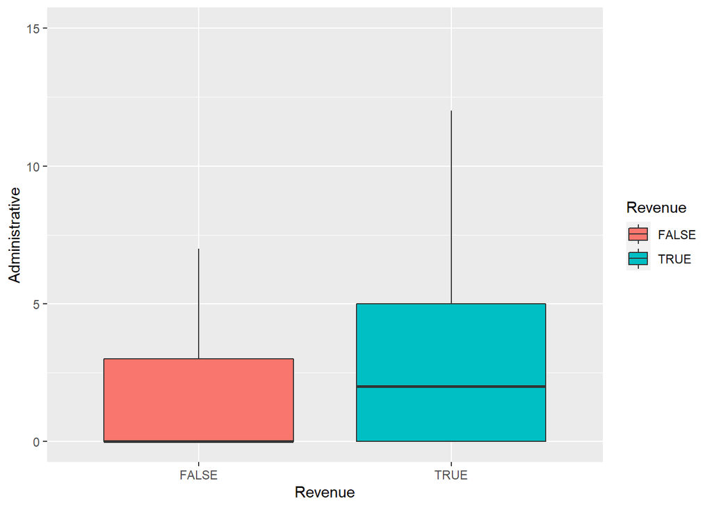

```r
dat %>% select(Administrative, Revenue) %>%

  ggplot(aes(x=Revenue, y=Administrative, fill=Revenue)) +
 geom_boxplot(outlier.shape = NA) +
 ylim(NA, 15)
```

```r
  labs(x="True/False", y="Revenues",
       title="Administrative/Revenue") +
  theme(plot.title=element_text(hjust=0.5))
```

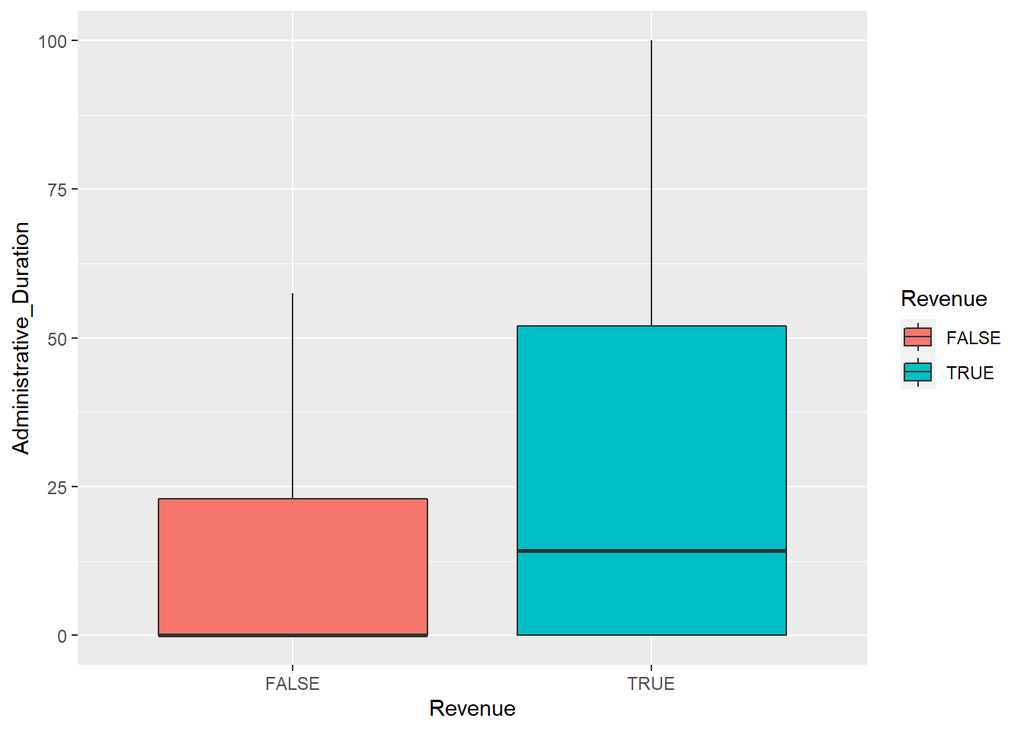

```r
dat %>% select(Administrative_Duration, Revenue) %>%

  ggplot(aes(x=Revenue, y=Administrative_Duration, fill=Revenue)) +
 geom_boxplot(outlier.shape = NA) +
 ylim(NA, 100)
```

```r
  labs(x="True/False", y="Revenues",
       title="Administrative_Duration/Revenue") +
  theme(plot.title=element_text(hjust=0.5))
```

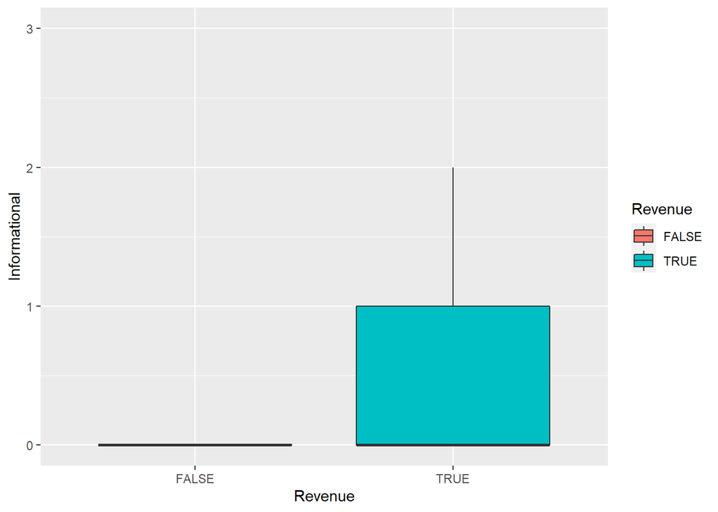

```r
dat %>% select(Informational, Revenue) %>%

  ggplot(aes(x=Revenue, y=Informational, fill=Revenue)) +
 geom_boxplot(outlier.shape = NA) +
 ylim(NA, 3)
```

```r
  labs(x="True/False", y="Revenues",
       title="Informational/Revenue") +
  theme(plot.title=element_text(hjust=0.5))
```

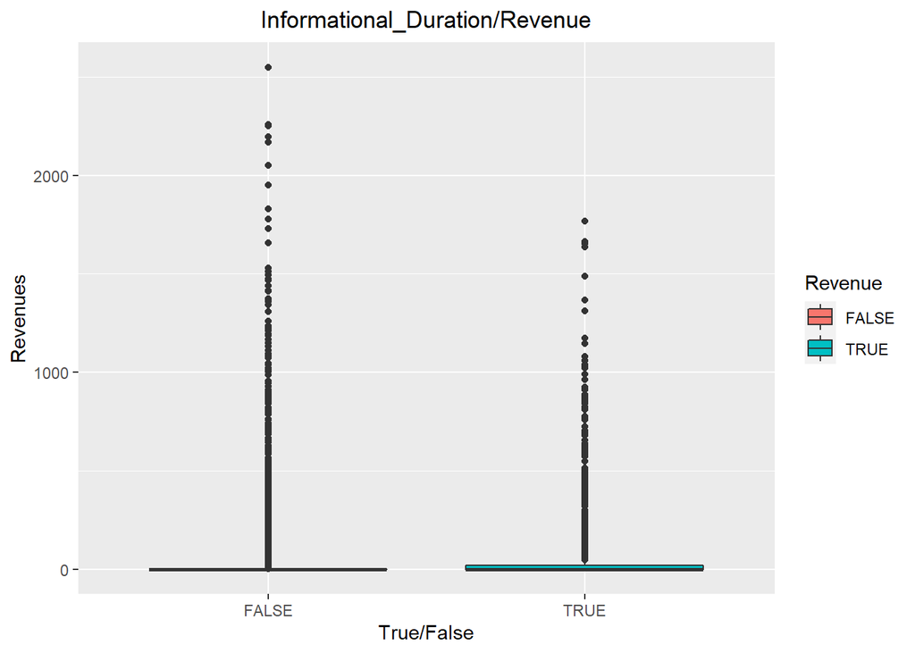

```r
dat %>% select(Informational_Duration, Revenue) %>%

  ggplot(aes(x=Revenue, y=Informational_Duration, fill=Revenue)) +
  geom_boxplot() +

  labs(x="True/False", y="Revenues",
       title="Informational_Duration/Revenue") +
  theme(plot.title=element_text(hjust=0.5))
```

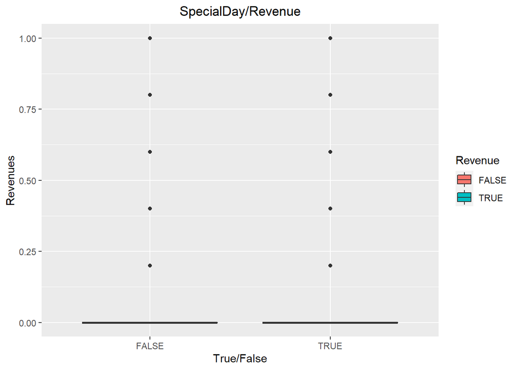

```r
dat %>% select(SpecialDay, Revenue) %>%

  ggplot(aes(x=Revenue, y=SpecialDay, fill=Revenue)) +
  geom_boxplot() +

  labs(x="True/False", y="Revenues",
       title="SpecialDay/Revenue") +
  theme(plot.title=element_text(hjust=0.5))
```

From the above boxplot, I tried to see the relationship between revenue to each numeric variable. the result from SpecialDay/Revenue and Informational_Duration/Revenue boxplots are no different between buyers and non-buyers. Other numeric variable like BounceRates/Revenue, ExitRates/Revenue, ProductRelated/Revenue has huge different count of revenue which are valuable to further invest PageValues/Revenue are the most significant different which true boxplot are highest then False.

# Missing data analysis

The following program analyzes the missing data in the dataset.

```r
cat("Missing by count\n")
```

```
## Missing by count
```

```r
sapply(dat[,1:15], function(x) round(sum(is.na(x)),2))
```

```
##          Administrative Administrative_Duration           Informational
##                       0                       0                       0
##  Informational_Duration          ProductRelated ProductRelated_Duration
##                       0                       0                       0
##             BounceRates               ExitRates              PageValues
##                       0                       0                       0
##              SpecialDay                   Month        OperatingSystems
##                       0                       0                       0
##                 Browser                  Region             TrafficType
##                       0                       0                       0
```

```r
cat("Missing by percentage\n")
```

```
## Missing by percentage
```

```r
sapply(dat[,1:15], function(x) round(sum(is.na(x))/nrow(dat),2))
```

```
##          Administrative Administrative_Duration           Informational
##                       0                       0                       0
##  Informational_Duration          ProductRelated ProductRelated_Duration
##                       0                       0                       0
##             BounceRates               ExitRates              PageValues
##                       0                       0                       0
##              SpecialDay                   Month        OperatingSystems
##                       0                       0                       0
##                 Browser                  Region             TrafficType
##                       0                       0                       0
```

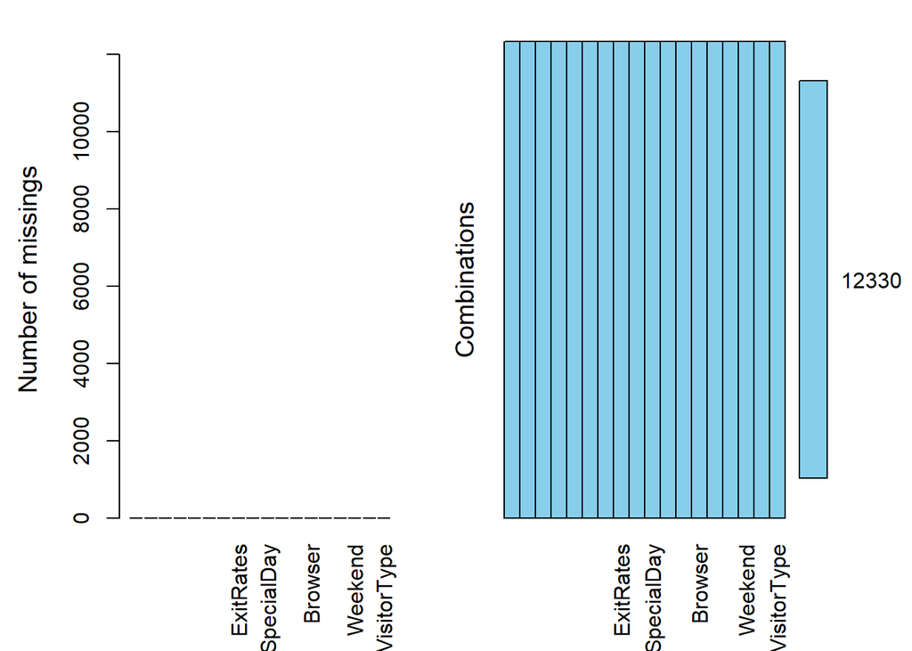

```r
aggr(dat, prop=FALSE, numbers=TRUE)
```

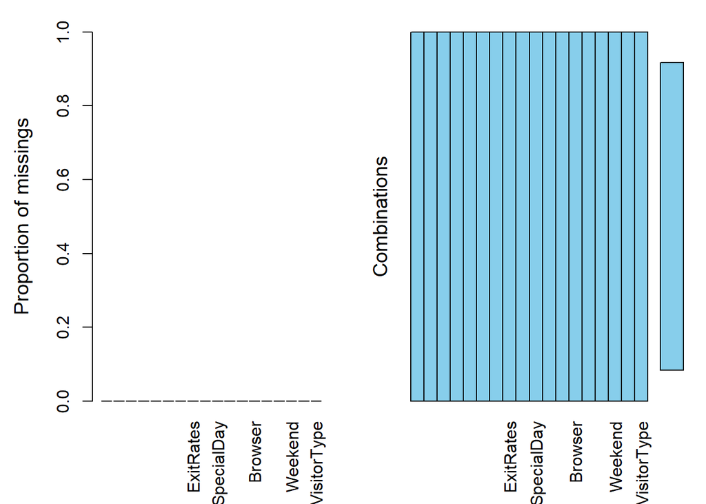

```r
aggr(dat, prop=TRUE, numbers=FALSE)
```

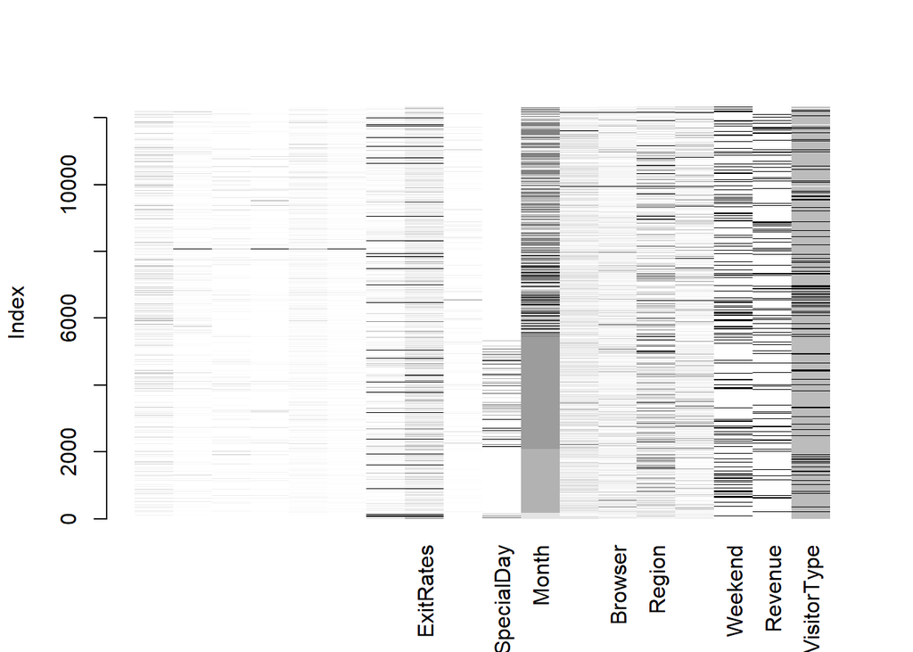

```r
matrixplot(dat, interactive=FALSE) # without sorting
```

The data has zero missing value,Which is perfectly fine for fruther investgation.

```r
dat_comp <- dat[complete.cases(dat),]
```

## Correlation analysis

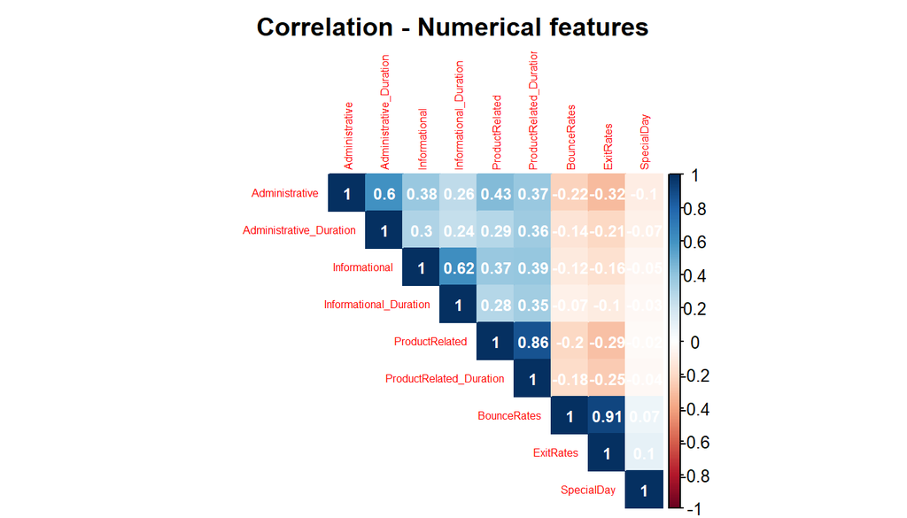

```r
dat %>%
  select(Administrative:ProductRelated_Duration,BounceRates,ExitRates,SpecialDay) %>%
  cor() %>%
  round(3) %>%
  corrplot(method = "color", addCoef.col="white", type = "upper",
           title="Correlation - Numerical features",
           mar=c(0,0,2,0),
           tl.cex=0.5, number.cex = 0.75)
```

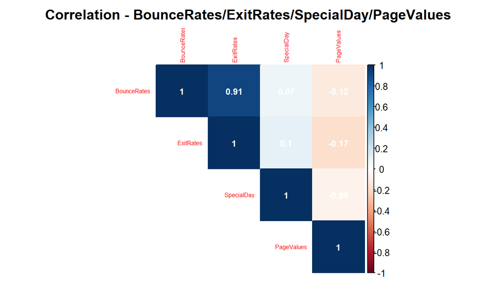

```r
dat %>%
  select(BounceRates,ExitRates,SpecialDay,PageValues) %>%
  cor() %>%
  round(3) %>%
  corrplot(method = "color", addCoef.col="white", type = "upper",
           title="Correlation - BounceRates/ExitRates/SpecialDay/PageValues",
           mar=c(0,0,2,0),
           tl.cex=0.5, number.cex=0.75)
```

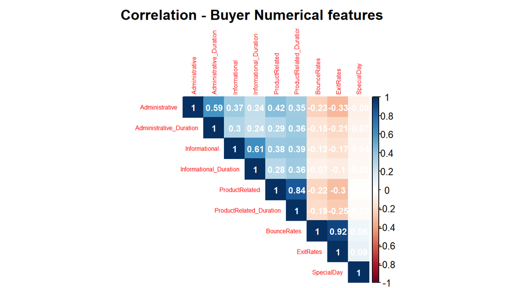

```r
datonlynotfinish_transaction <- dat %>% filter(Revenue!= TRUE)
datonlynotfinish_transaction  %>%
  select(Administrative:ProductRelated_Duration,BounceRates,ExitRates,SpecialDay) %>%
  cor() %>%
  round(3) %>%
  corrplot(method = "color", addCoef.col="white", type = "upper",
           title="Correlation - Buyer Numerical features",
           mar=c(0,0,2,0),
           tl.cex=0.5, number.cex = 0.75)
```

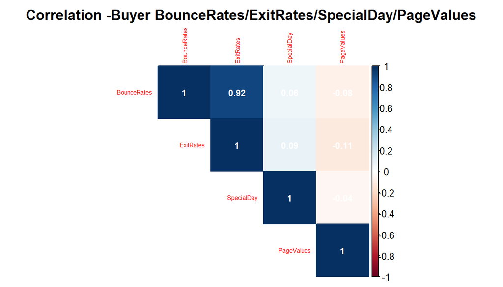

```r
datonlynotfinish_transaction <- dat %>% filter(Revenue!= TRUE)
datonlynotfinish_transaction  %>%
  select(BounceRates,ExitRates,SpecialDay,PageValues) %>%
  cor() %>%
  round(3) %>%
  corrplot(method = "color", addCoef.col="white", type = "upper",
           title="Correlation -Buyer BounceRates/ExitRates/SpecialDay/PageValues",
           mar=c(0,0,2,0),
           tl.cex=0.5, number.cex=0.75)
```

The following rule of thumb is applied to evaluate the correlations between variables:

| Correlation coefficient | Interpretation |
| --- | --- |
| 0.90 - 1.00 | Very strong correlation |
| 0.70 - 0.89 | Strong correation |
| 0.40 - 0.69 | Moderate correation |
| 0.10 - 0.39 | Weak correation |
| 0.00 - 0.10 | Negligible correation |

From the correlation plots, For Pagevalues attributes, moderate to strong correlations include:

[output not shown]

Form Corrplot, the result of strong correlations Variables is quite natural because when users visiting the page of ProductRelated increase the time (ProductRelated_Duration) will increase too. Same as Administrative_Duration/Administrative (0.6); Informational_Duration/Informational (0.62). Also the BounceRates/ExitRates(0.9)when users leave the pages also count in exit rates. Which can’t make any impact for customer purchasing intention.

[output not shown]

## Data analysis and hypothesis

I am going to discover the relationship between (Administrative, Informational, ProductRelated) number of pages visited by the visitor and the buyers and non-buyers by filter the Revenue and make hypothesis.

H1: Administrative, Informational, ProductRelated number of pages visited by the buyers and non-buyers. Buyers will have higher pages visited.

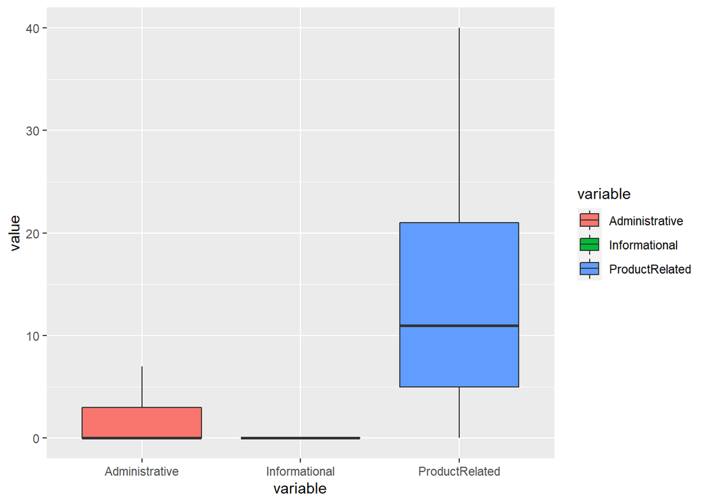

```r
library(dplyr)
datonlynotfinish_transaction <- dat %>% filter(Revenue!= TRUE)
datonlynotfinish_transaction %>% select(PageValues, Administrative, Informational, ProductRelated) %>%
   reshape2::melt(id="PageValues") %>%
  ggplot(aes(x=variable, y=value, fill=variable)) +
  geom_boxplot(outlier.shape = NA) +
  ylim(NA, 40)
```

```r
  labs(x="Characterisitcs", y="PageValues",
       title="contain false in Revenue") +
  theme(plot.title=element_text(hjust=0.5))
```

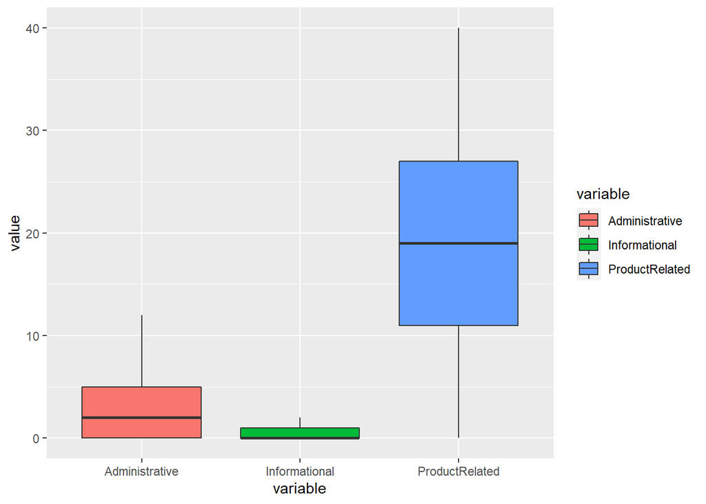

```r
library(dplyr)
datonlyfinish_transaction <- dat %>% filter(Revenue!= FALSE)
datonlyfinish_transaction %>% select(PageValues, Administrative, Informational, ProductRelated ) %>%
  reshape2::melt(id="PageValues") %>%
  ggplot(aes(x=variable, y=value, fill=variable)) +
  geom_boxplot(outlier.shape = NA) +
  ylim(NA, 40)
```

```r
  labs(x="Characterisitcs", y="PageValues",
       title="contain true in Revenue") +
  theme(plot.title=element_text(hjust=0.5))
```

H2:buyers will have lowerExitRates,BounceRates

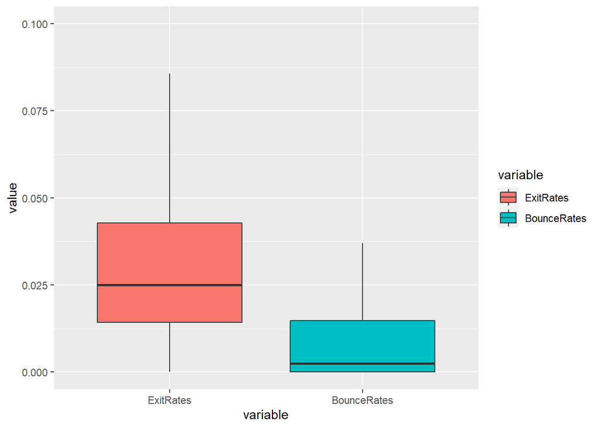

```r
library(dplyr)

datonlynotfinish_transaction <- dat %>% filter(Revenue!= TRUE)
datonlynotfinish_transaction %>% select(Revenue,ExitRates, BounceRates ) %>%
  reshape2::melt(id="Revenue") %>%
  ggplot(aes(x=variable, y=value, fill=variable)) +
  geom_boxplot(outlier.shape = NA) +
  ylim(NA, 0.10
       )
```

```r
  labs(x="Characterisitcs", y="Revenue",
       title="All the variable") +
  theme(plot.title=element_text(hjust=0.5))
```

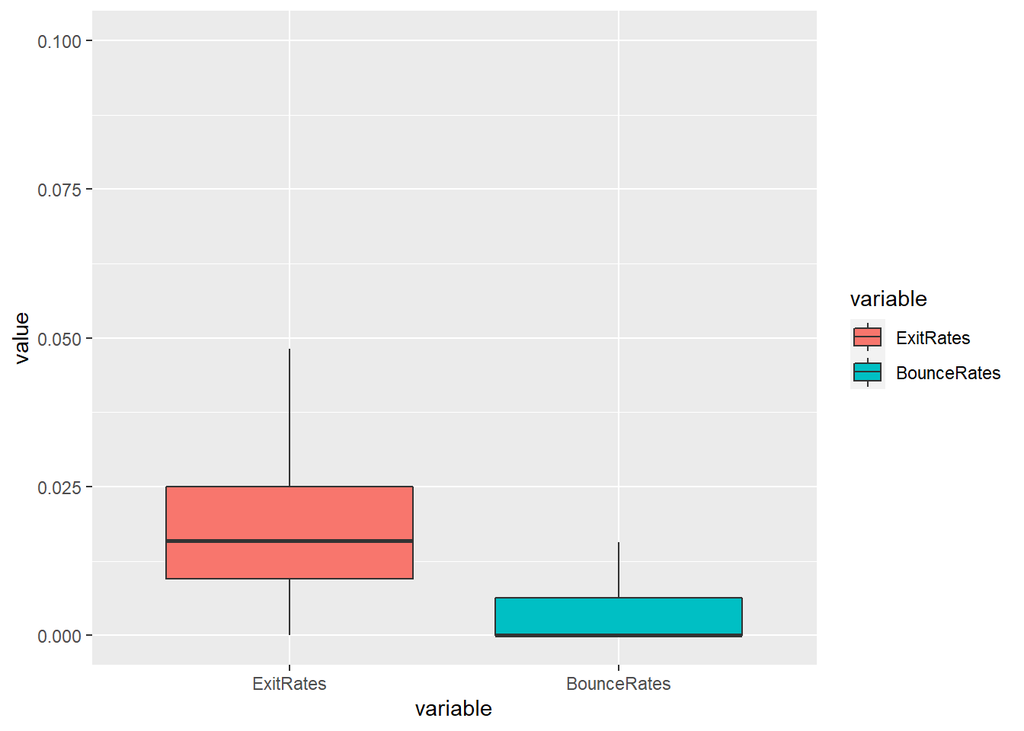

```r
library(dplyr)
datonlyfinish_transaction <- dat %>% filter(Revenue!= FALSE)
datonlyfinish_transaction %>% select(Revenue,ExitRates, BounceRates ) %>%

  reshape2::melt(id="Revenue") %>%
  ggplot(aes(x=variable, y=value, fill=variable)) +
  geom_boxplot(outlier.shape = NA) +
  ylim(NA, 0.10
       )
```

```r
  labs(x="Characterisitcs", y="PageValues",
       title="All the variable") +
  theme(plot.title=element_text(hjust=0.5))
```

After using the filter function to separate the ExitRates and BounceRates from buyers and non-buyers. We know that buyers have 0.015 to 0.025 ExitRates and 0 to 0.008 BounceRates and non-buyers have higher ExitRates and BounceRates 0.016 to 0.040 and 0.00 to 0.016. It means the users who have buying intention usually not going exit and bounce the pages in higher frequency. It’s likelihood to people who abandon the page usually higher exit Rates and bounce Rate.

H3 Revenue and Weekend relate to each other.

```r
table(dat$Weekend ,dat$Revenue)
```

```
##
##         FALSE TRUE
##   FALSE  8053 1409
##   TRUE   2369  499
```

```r
chisq.test(dat$Weekend  ,dat$Revenue, correct=FALSE)
```

```
##
##  Pearson's Chi-squared test
##
## data:  dat$Weekend and dat$Revenue
## X-squared = 10.582, df = 1, p-value = 0.001142
```

We have a chi-squared value of 10.582. Since we get a p-Value less than the significance level of 0.05, we reject the null hypothesis and conclude that the two variables are in fact dependent.

H4 Revenue and Month relate to each other.

```r
table(dat$Month ,dat$Revenue)
```

```
##
##        FALSE TRUE
##   Aug    357   76
##   Dec   1511  216
##   Feb    181    3
##   Jul    366   66
##   June   259   29
##   Mar   1715  192
##   May   2999  365
##   Nov   2238  760
##   Oct    434  115
##   Sep    362   86
```

```r
chisq.test(dat$Month  ,dat$Revenue, correct=FALSE)
```

```
##
##  Pearson's Chi-squared test
##
## data:  dat$Month and dat$Revenue
## X-squared = 384.93, df = 9, p-value < 2.2e-16
```

We have a chi-squared value of 384.93. Since we get a p-Value less than the significance level of 0.05, we reject the null hypothesis and conclude that the two variables are in fact dependent.

H5 Revenue and Region relate to each other.

```r
table(dat$Region ,dat$Revenue)
```

```
##
##     FALSE TRUE
##   1  4009  771
##   2   948  188
##   3  2054  349
##   4  1007  175
##   5   266   52
##   6   693  112
##   7   642  119
##   8   378   56
##   9   425   86
```

```r
chisq.test(dat$Region ,dat$Revenue, correct=FALSE)
```

```
##
##  Pearson's Chi-squared test
##
## data:  dat$Region and dat$Revenue
## X-squared = 9.2528, df = 8, p-value = 0.3214
```

We have a chi-squared value of 9.2528. Since we get a p-Value higher than the significance level of 0.05, we reject the H1 that the two variables are relate to each other.

```r
table(dat$VisitorType ,dat$Revenue)
```

```
##
##      FALSE TRUE
##   -1    69   16
##   0   9081 1470
##   1   1272  422
```

```r
chisq.test(dat$VisitorType ,dat$Revenue, correct=FALSE)
```

```
##
##  Pearson's Chi-squared test
##
## data:  dat$VisitorType and dat$Revenue
## X-squared = 135.25, df = 2, p-value < 2.2e-16
```

We have a chi-squared value of 135.25. Since we get a p-Value lower than the significance level of 0.05, we reject the H0 that the two variables are not relate to each other.

Form the above test we found that Revenue are relate to Month, Weekend, Visitor Type those Categorical variables We can customized promotions during November and May, which is the most shopping period for shoppers. since the transaction is high is those months. Also, Weekdays have more transaction and we should focus on Returning Visitor.